# Chapter_5

# Chapter 5: Multiple Regression

Note right off the bat I’ve changed the chapter title here from Multivariate models to Multiple Regression. Just want to make a little clarifying note there that Multivariate models are really models that have multiple response variables and thus involve estimating/predicting parameters of a multivariate distribution - like a vector of means for a multivariate Gaussian. A multiple regression, which is what McElreath is really dealing with here, has multiple predictors but a single response variable. Anyways.

We start off with a discussion of the Waffle House divorce rate correlation. This leads to an introduction to **Confounds**, which McElreath broadly defines as a variable that is correlated to a variable of interest. These can be spurious (and thus mask a meaningful relationsip), as in the case of the Waffle House-divorce relationship, but they can also be meaningful, like in Simpson’s paradox. In Simpson’s paradox, controlling for a confound actually reverses the relationship between a response variable and a meaningful predictor. There’s a great dataset using penguins which I’ll show below:

```r
#install.packages('palmerpenguins')
library(palmerpenguins)
library(tidyverse)
library(dplyr)
peng_df <- palmerpenguins::penguins%>%na.omit()
str(peng_df)
```

```
## tibble [333 × 8] (S3: tbl_df/tbl/data.frame)
##  $ species          : Factor w/ 3 levels "Adelie","Chinstrap",..: 1 1 1 1 1 1 1 1 1 1 ...
##  $ island           : Factor w/ 3 levels "Biscoe","Dream",..: 3 3 3 3 3 3 3 3 3 3 ...
##  $ bill_length_mm   : num [1:333] 39.1 39.5 40.3 36.7 39.3 38.9 39.2 41.1 38.6 34.6 ...
##  $ bill_depth_mm    : num [1:333] 18.7 17.4 18 19.3 20.6 17.8 19.6 17.6 21.2 21.1 ...
##  $ flipper_length_mm: int [1:333] 181 186 195 193 190 181 195 182 191 198 ...
##  $ body_mass_g      : int [1:333] 3750 3800 3250 3450 3650 3625 4675 3200 3800 4400 ...
##  $ sex              : Factor w/ 2 levels "female","male": 2 1 1 1 2 1 2 1 2 2 ...
##  $ year             : int [1:333] 2007 2007 2007 2007 2007 2007 2007 2007 2007 2007 ...
##  - attr(*, "na.action")= 'omit' Named int [1:11] 4 9 10 11 12 48 179 219 257 269 ...
##   ..- attr(*, "names")= chr [1:11] "4" "9" "10" "11" ...
```

```r
head(peng_df)
```

```
## # A tibble: 6 × 8
##   species island bill_length_mm bill_depth_mm flipper_length_… body_mass_g sex
##   <fct>   <fct>           <dbl>         <dbl>            <int>       <int> <fct>
## 1 Adelie  Torge…           39.1          18.7              181        3750 male
## 2 Adelie  Torge…           39.5          17.4              186        3800 fema…
## 3 Adelie  Torge…           40.3          18                195        3250 fema…
## 4 Adelie  Torge…           36.7          19.3              193        3450 fema…
## 5 Adelie  Torge…           39.3          20.6              190        3650 male
## 6 Adelie  Torge…           38.9          17.8              181        3625 fema…
## # … with 1 more variable: year <int>
```

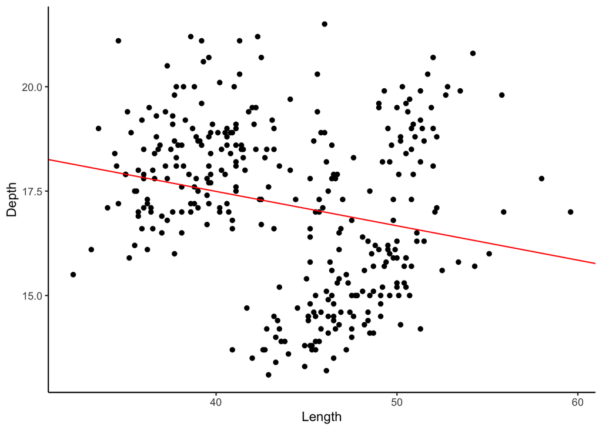

```r
#First we plot it our data as if all penguins were one population - so not controlling for species.

mod_simpsons <- lm(bill_depth_mm~bill_length_mm, data=peng_df)

peng_df%>%
  ggplot(aes(x=bill_length_mm, y=bill_depth_mm))+
  geom_point()+
  geom_abline(slope=mod_simpsons$coefficients[[2]],
              intercept = mod_simpsons$coefficients[[1]],
              color='red')+
  labs(x='Length', y='Depth')+ theme_classic()
```

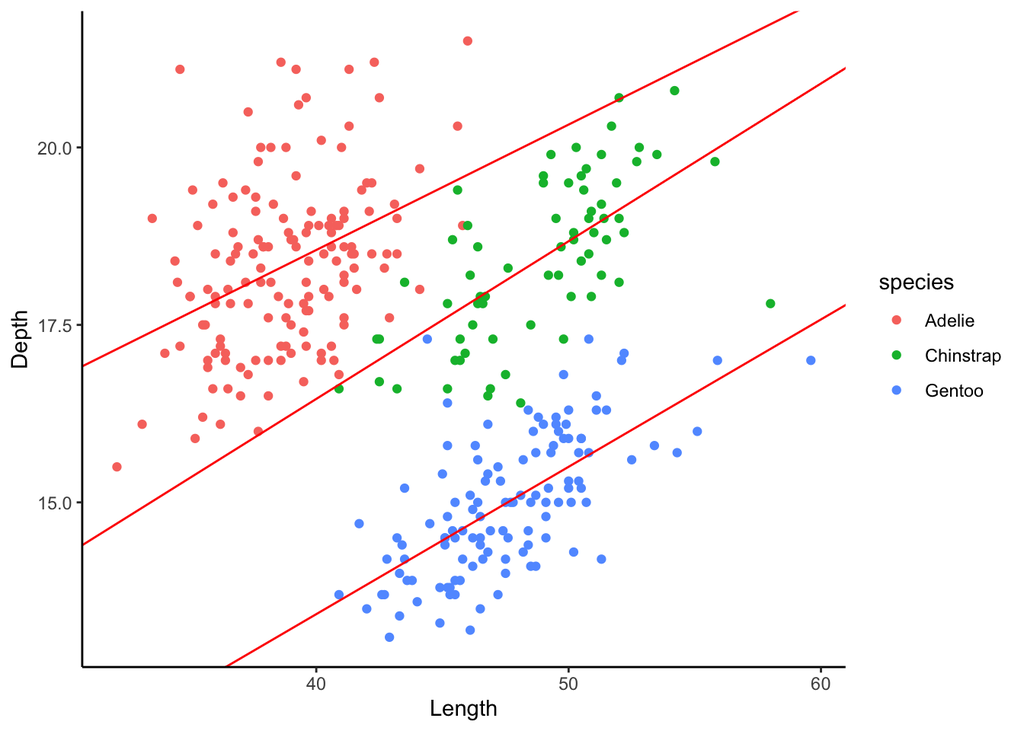

[output not shown]

[output not shown]

[output not shown]

[output not shown]

[output not shown]

[output not shown]

[output not shown]

[output not shown]

[output not shown]

[output not shown]

```
##  Family: gaussian
##   Links: mu = identity; sigma = identity
## Formula: bill_depth_mm ~ bill_length_mm
##    Data: peng_df (Number of observations: 333)
##   Draws: 4 chains, each with iter = 2000; warmup = 1000; thin = 1;
##          total post-warmup draws = 4000
##
## Population-Level Effects:
##                Estimate Est.Error l-95% CI u-95% CI Rhat Bulk_ESS Tail_ESS
## Intercept         20.77      0.86    19.03    22.48 1.00     4198     3008
## bill_length_mm    -0.08      0.02    -0.12    -0.04 1.00     4064     3008
##
## Family Specific Parameters:
##       Estimate Est.Error l-95% CI u-95% CI Rhat Bulk_ESS Tail_ESS
## sigma     1.92      0.07     1.79     2.08 1.00     4049     2943
##
## Draws were sampled using sampling(NUTS). For each parameter, Bulk_ESS
## and Tail_ESS are effective sample size measures, and Rhat is the potential
## scale reduction factor on split chains (at convergence, Rhat = 1).
```

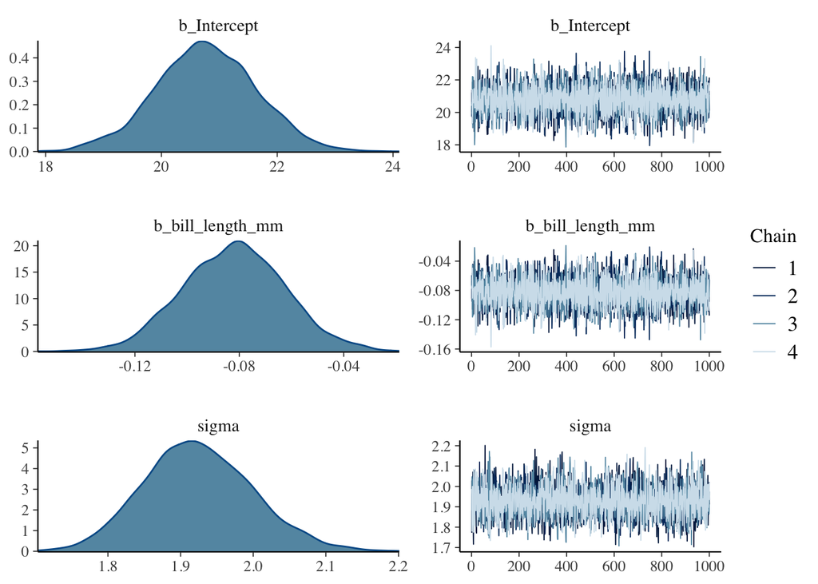

```
##  Family: gaussian
##   Links: mu = identity; sigma = identity
## Formula: scale(bill_depth_mm) ~ scale(bill_length_mm)
##    Data: peng_df (Number of observations: 333)
##   Draws: 4 chains, each with iter = 2000; warmup = 1000; thin = 1;
##          total post-warmup draws = 4000
##
## Population-Level Effects:
##                     Estimate Est.Error l-95% CI u-95% CI Rhat Bulk_ESS Tail_ESS
## Intercept               0.00      0.05    -0.10     0.10 1.00     4461     3135
## scalebill_length_mm    -0.23      0.05    -0.34    -0.12 1.00     4295     2893
##
## Family Specific Parameters:
##       Estimate Est.Error l-95% CI u-95% CI Rhat Bulk_ESS Tail_ESS
## sigma     0.98      0.04     0.91     1.06 1.00     4184     2768
##
## Draws were sampled using sampling(NUTS). For each parameter, Bulk_ESS
## and Tail_ESS are effective sample size measures, and Rhat is the potential
## scale reduction factor on split chains (at convergence, Rhat = 1).
```

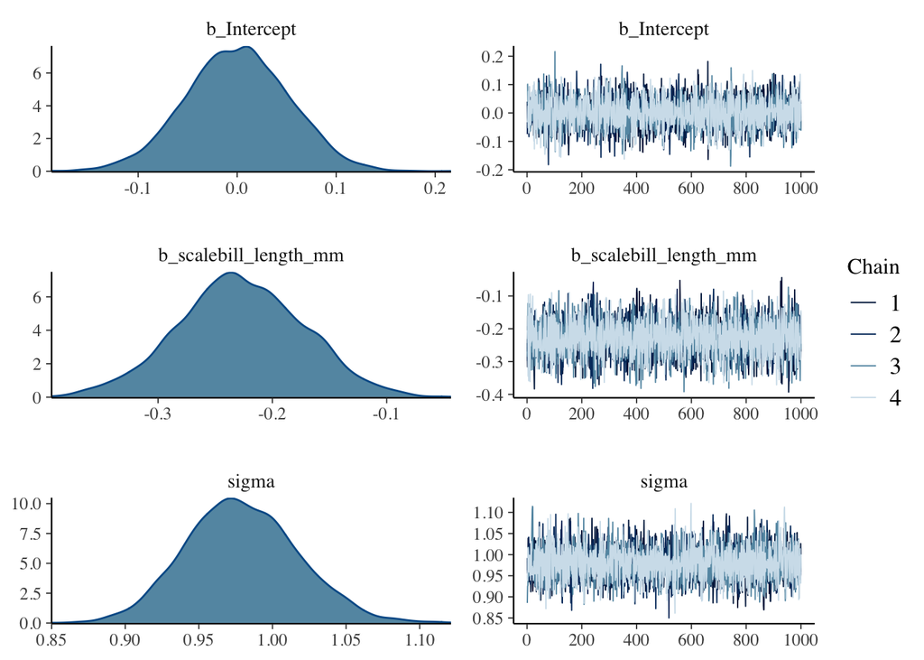

Now we see that when we stratify the linear relationship based on species, we have literally the opposite relationship - each species has a positive relationship between bill length and depth. Thus the relationship between bill length and depth has a confound, species, which will change the nature of the relationship. This has real meaning in the system as well, in that species do differ in their body sizes and thus by not controlling for a sort of morphological generalization, we misrepresent the relationship between the two variables! So confounds are not inherently useless (although I’d also argue that the Waffle House confound has some interesting meaning w/r/t Southerness, but whatever).

##### Rethinking: Causal Inference

Basically, here McElreath just points out that there isn’t actually a good consistent set of best practices for causal inference in the sciences or in statistics. It is always a sort of gray area built around unverifiable assumptions and experimental control. In complex dynamical systems, causality may not even have real meaning in that everything can drive change in everything else! So it’s always good to keep that in mind when we talk about relating mechanistic or causal hypotheses to statistical models like these.

### 5.3 - When adding variables hurts

Lets just jump straight into multicollinearity yeah?

Looking at what happens when we try and predict height using the length of both legs rather than just one.

```r
library(rethinking)
```

```r
N <- 100
heights <- rnorm(N, 10, 2)
leg_prop <- runif(N, 0.4, 0.5)
leg_left <- heights*leg_prop+rnorm(N,0,0.02)
leg_right <- heights*leg_prop+rnorm(N,0,0.02)

d <- data.frame(heights, leg_left, leg_right)


m5.8 <- rethinking::map(alist(
  heights ~ dnorm(mu, sigma),
  mu <- a + bl*leg_left+br*leg_right,
  a~dnorm(10,100),
  bl~dnorm(2,10),
  br~dnorm(2, 10),
  sigma~dunif(0,10)
),
data=d)

precis(m5.8)
```

```
##             mean         sd       5.5%     94.5%
## a      1.1063337 0.29799908  0.6300736 1.5825938
## bl    -1.8081593 2.29663820 -5.4786307 1.8623121
## br     3.7952750 2.30477254  0.1118033 7.4787467
## sigma  0.6539956 0.04625138  0.5800770 0.7279143
```

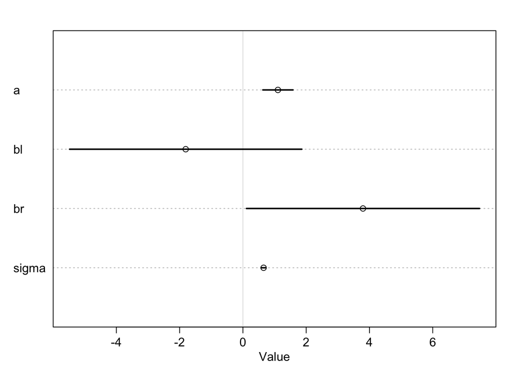

```r
plot(precis(m5.8))
```

The main thing to watch here is the mean and standard deviation for bl and br. They are not great - standard devs are massive relative to the parameter estimates. So we have a lot of uncertainty around the effect that each leg has in predicting height.

The key question of a multiple regression is: what is the value of knowing this predictor after knowing all the other predictors? So in this case, it would be: what is the value of knowing the value of one leg length after already knowing the other?

The posterior is the answer to this - conditioned on all of the possible permutations of bl and br.

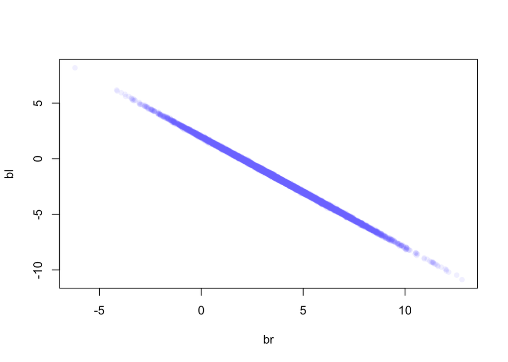

```r
post <- extract.samples(m5.8)

plot(bl~br, post, col=col.alpha(rangi2, 0.1), pch=16)
```

Here we plot the two coefficients against one another and show they are strongly negatively correlated. When bl is large br must by definition be small.

The tricky part here is how optimization sort of occurs. As McElreath describes it, you can look at our likelihood as this function:

$y_{i}\sim Normal(\mu_{i}, \sigma)$ $\mu_{i} = \alpha + (\beta_{1}+\beta_{2})x_{i}$

The trick here is that we have factored out our $x_{i}$ terms. What this ends up showing us is that neither $\beta$ ever influences $\mu$ on its own. Instead, it is the sum of the two terms. As a result, the posterior shows all of the possible combinations of $\beta_{1}$ and $\beta_{2}$ that could match the strength of the association between leg length and height. So we end up with lots of equivalent parameterizations of the model.

So really we end up with a posterior for the SUM of the two coefficients as the strength of the association:

```r
sum_blbr <- post$bl+post$br

mean(sum_blbr)
```

```
## [1] 1.98669
```

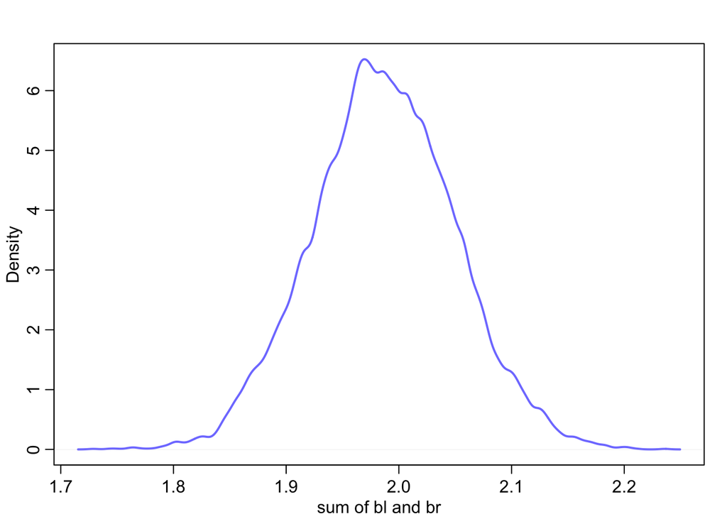

```r
dens(sum_blbr, col = rangi2, lwd = 2, xlab = ("sum of bl and br"))
```

```r
#now fit the model with just one leg to see if the estimate is close to our mean of the sum.

m5.9 <- rethinking::map(alist(
  heights ~ dnorm(mu, sigma),
  mu <- a + bl*leg_left,
  a~dnorm(10,100),
  bl~dnorm(2,10),
  sigma~dunif(0,10)
),
data=d)

precis(m5.9)
```

```
##            mean         sd      5.5%     94.5%
## a     1.1711463 0.29958331 0.6923544 1.6499383
## bl    1.9722766 0.06355144 1.8707091 2.0738440
## sigma 0.6632488 0.04689784 0.5882970 0.7382006
```

When you run precis, you’ll see that our mean for bl is just about the same as the mean for the sum of the two coefficients. So the pairs of coefficients still described the strength of the association, but sort of randomly decomposed into two complementary components - one for the left leg one for the right leg.

```r
data(milk)

d <- milk
```

```r
dummy_data <- seq(0,10,1)

fit_func <- function(x, theta, gam){
  fit <- exp(-gam*((x-theta)^2))
  return(fit)
}

fit_func(dummy_data, 5, -0.2)
```

```
##  [1] 148.413159  24.532530   6.049647   2.225541   1.221403   1.000000
##  [7]   1.221403   2.225541   6.049647  24.532530 148.413159
```